# Домашнее задание: Многомерный анализ данных

Метаболический синдром - применение PCA и методов кластеризации

Пороло Виктория

2025-12-15

# 1 Введение

## 1.1 О датасете

В этом домашнем задании мы будем работать с датасетом **Metabolic Syndrome**, содержащим клинические и биохимические показатели пациентов.

**Метаболический синдром** - это комплекс взаимосвязанных нарушений обмена веществ, включающий ожирение, инсулинорезистентность, дислипидемию и артериальную гипертензию. Этот синдром значительно повышает риск развития сердечно-сосудистых заболеваний и диабета 2 типа.

Датасет включает следующие показатели:

- **Антропометрические данные**: возраст, окружность талии, ИМТ
- **Метаболические показатели**: уровень глюкозы, триглицеридов, холестерина (HDL)
- **Биохимические маркеры**: альбумин в моче (UrAlbCr)
- **Социально-экономический статус**: уровень дохода (Его мы не будем использовать в анализе)

Цель работы - применить методы многомерного анализа (PCA) и кластеризации для выявления структуры данных и классификации пациентов по наличию метаболического синдрома.

## 1.2 Задачи домашнего задания

1. Провести исследовательский анализ данных (EDA)
2. Выполнить предобработку и масштабирование данных
3. Применить методы снижения размерности (PCA, UMAP)
4. Определить оптимальное количество главных компонент
5. Интерпретировать результаты PCA
6. Применить методы кластеризации (иерархическая, K-means)
7. Сравнить качество кластеризации различными методами

# 2 Загрузка и подготовка данных

## 2.1 Загрузка датасета

Зарегистрируйтесь на платформе Kaggle и скачайте датасет: [Metabolic Syndrome Dataset](https://www.kaggle.com/datasets/antimoni/metabolic-syndrome)

```r
file <- "C:/Users/vtish/Desktop/datasets & books (Bioinformatics)/Biostat2024/Визуализация Данных в R/домашки/20.11/Metabolic Syndrome.csv"
# Загрузка данных
data <- fread(file) %>%
  select(-seqn, -Sex, -Marital, -Race, -Albuminuria, -Income)

# Удаление пропущенных значений
data <- data %>% na.omit()

# Сохранение целевой переменной
target <- data$MetabolicSyndrome %>% as.factor()
data$MetabolicSyndrome <- NULL

# Проверка размерности
cat("Размер датасета:", nrow(data), "наблюдений,", ncol(data), "переменных\n\n")
```

```
## Размер датасета: 2311 наблюдений, 8 переменных
```

```r
cat("Распределение классов:\n")
```

```
## Распределение классов:
```

```r
table(target)
```

```
## target
##    0    1
## 1508  803
```

# 3 Исследовательский анализ данных (EDA)

## 3.1 Визуализация взаимосвязей между переменными

Для комплексного анализа взаимосвязей между всеми переменными используем функцию `ggpairs()`, которая строит матрицу диаграмм рассеяния, гистограмм и коэффициентов корреляции.

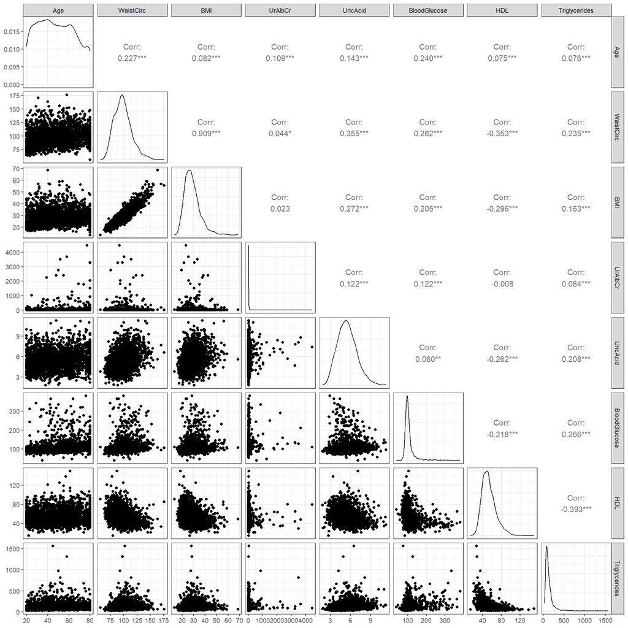

```r
# Ваш код здесь
ggpairs(data)
```

### 3.1.1 Вопрос 1: Анализ распределений

**Вопрос:** Какие переменные имеют правостороннюю асимметрию (скошены вправо, имеют длинный хвост вправо)?

**Ответ:** Переменные **UrAlbCr, Triglycerides, BloodGlucose.**

# 4 Предобработка данных

## 4.1 Логарифмирование переменных

Для переменных с сильной правосторонней асимметрией применяем логарифмическое преобразование, которое помогает: - Нормализовать распределение - Уменьшить влияние выбросов - Стабилизировать дисперсию

Применяем `log1p()` (логарифм с добавлением 1), чтобы избежать проблем с нулевыми значениями:

```r
# Логарифмируем UrAlbCr (переменную с наиболее выраженной асимметрией)

data2 <- data %>%
  mutate(
    UrAlbCr = log1p(UrAlbCr),
    BloodGlucose = log1p(BloodGlucose),
    Triglycerides = log1p(Triglycerides)
  )
```

## 4.2 Масштабирование данных

Для корректной работы методов многомерного анализа необходимо стандартизировать данные (масштабирование к нулевому среднему и единичной дисперсии).

```r
data_scale <- as.data.frame(scale(data2))
head(data_scale)
```

```
##          Age  WaistCirc         BMI     UrAlbCr    UricAcid BloodGlucose
## 1 -1.5061193 -1.0644154 -0.81809307 -0.73431544 -0.40295082  -0.55381672
## 2 -0.2492812 -1.1198000 -0.83331846 -0.10199328 -0.68276432  -1.05350003
## 3 -1.5632483 -1.7659537 -1.30530562 -0.52880160 -0.05318394   0.10299800
## 4 -0.3064102  1.3601994  0.70444615 -0.50581098 -0.33299744  -0.02074193
## 5  0.1506218 -1.0582616 -1.30530562 -0.14435127 -0.33299744  -0.41436129
## 6  1.8073629  0.8740457 -0.02637267  0.01298063 -0.47290420   0.02089324
##          HDL Triglycerides
## 1 -0.8200516    -0.4544575
## 2 -1.6854120    -1.1900142
## 3 -0.6869192    -0.5892054
## 4  1.3100663     0.4901618
## 5 -0.6869192     0.2846625
## 6 -0.4206545    -0.1369878
```

### 4.2.1 Вопрос 2: Идентификация аутлайеров

**Вопрос:** Какие переменные имеют аутлайеры (выбросы > 3SD или < -3SD)? Отразите диапазон (range) каждой переменной в шкалированном датасете в виде таблицы/матрицы.

```r
range_df <- data.frame(
  Min = round(apply(data_scale, 2, min),2),
  Max = round(apply(data_scale, 2, max),2)
)

range_df
```

```
##                 Min  Max
## Age           -1.62 1.81
## WaistCirc     -2.59 4.78
## BMI           -2.33 6.09
## UrAlbCr       -1.40 5.69
## UricAcid      -2.57 4.07
## BloodGlucose  -4.26 5.66
## HDL           -2.62 6.44
## Triglycerides -2.57 4.91
```

**Ответ:**

Во всех переменных кроме (Age) обнаружены выбросы в > 3SD или/и < -3SD.

Выбросы >3SD имеют переменные: WaistCirc (-2.59:4.78), BMI (-2.33:6.09), UrAlbCr (-1.40:5.69), UricAcid (-2.57:4.07), Triglycerides (-2.57:4.91), HDL (-2.62:6.44).

Переменная BloodGlucose (-4.26:5.66) имеет выбросы > 3SD и < -3SD.

## 4.3 Замена аутлайеров

Для уменьшения влияния экстремальных значений примените замену значений >3SD на 3 и <-3SD на -3:

```r
data_scale_out <- data_scale %>%
  mutate(across(everything(), ~ pmax(pmin(., 3), -3)))
```

## 4.4 Визуализация обработанных данных

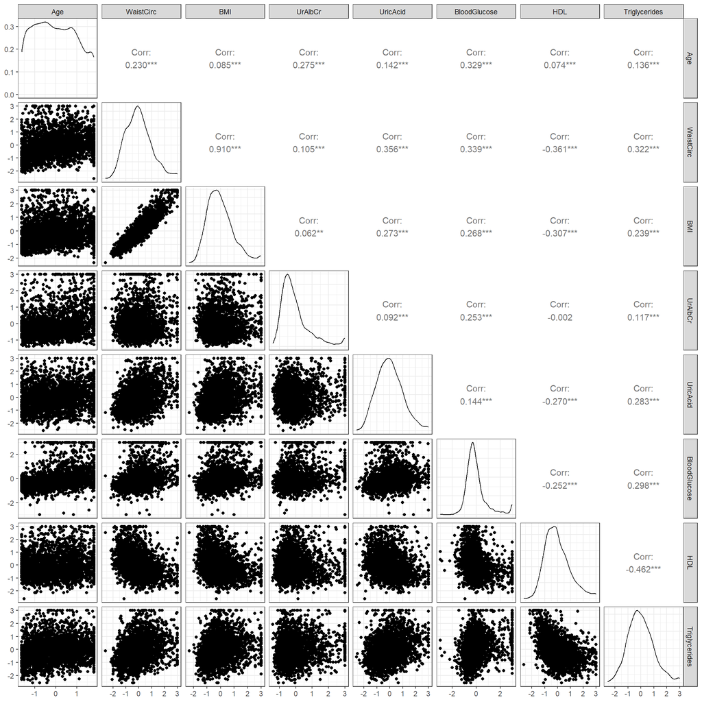

```r
ggpairs(data_scale_out)
```

# 5 Метод главных компонент (PCA)

## 5.1 Применение PCA

Метод главных компонент (PCA) - это линейное преобразование данных в новую систему координат, где: - Первая главная компонента объясняет максимальную долю вариации - Каждая последующая компонента объясняет максимум оставшейся вариации - Все компоненты ортогональны (некоррелированы) друг другу

```r
pca_result.ca<- prcomp(data_scale_out, scale = F)
summary(pca_result.ca)
```

```
## Importance of components:
##                           PC1    PC2    PC3    PC4     PC5     PC6     PC7
## Standard deviation     1.6431 1.1175 1.0096 0.8846 0.80055 0.71354 0.66041
## Proportion of Variance 0.3646 0.1686 0.1376 0.1057 0.08654 0.06875 0.05889
## Cumulative Proportion  0.3646 0.5332 0.6708 0.7765 0.86304 0.93179 0.99068
##                            PC8
## Standard deviation     0.26266
## Proportion of Variance 0.00932
## Cumulative Proportion  1.00000
```

## 5.2 Биплот: визуализация PCA

Биплот одновременно показывает: - **Наблюдения** (пациенты) - точки, окрашенные по диагнозу - **Переменные** - стрелки, указывающие направление максимального изменения

Постройте биплот используя fviz_pca_biplot(). Окрасьте точки по переменной target (диагноз)

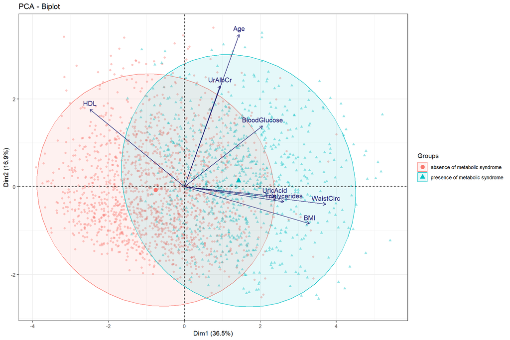

```r
target2 <- factor(target,
                  levels = c("0", "1"),
                  labels = c("absence of metabolic syndrome", "presence of metabolic syndrome"))

fviz_pca_biplot(
  pca_result.ca,
  geom = "point",
  habillage = target2,
  addEllipses = TRUE,
  ellipse.level = 0.95,
  alpha.ind = 0.4,
  col.var = "midnightblue",
  labelsize = 4
) +
  theme_bw()
```

### 5.2.1 Вопрос 3: Интерпретация биплота

**Вопрос 3.1:** Какие две переменные вносят наибольший вклад в PC2?

**Ответ:** Переменные **Age**(~52%) и **UrAlbCr** (~23%).

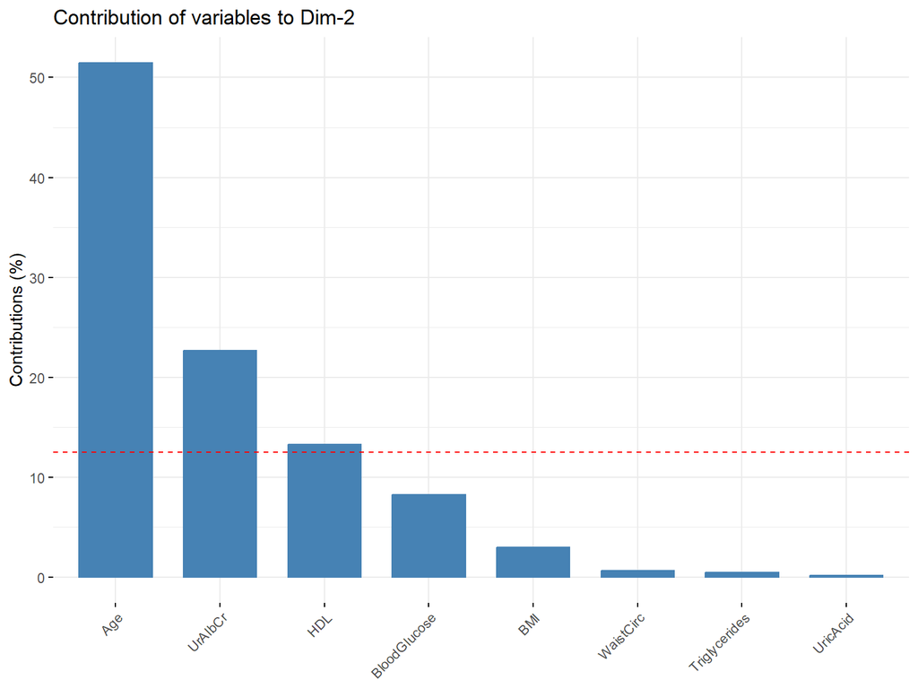

```r
fviz_contrib(pca_result.ca, choice = "var", axes = 2)
```

**Вопрос 3.2:** Какие три переменные вносят наибольший вклад в PC1?

**Ответ:** Переменные **WaistCirc** (~27%), **BMI**(~21%), **Triglycerides** (~13%).

**Вопрос 3.3:** Опишите, как в пространстве главных компонент разделяются наблюдения на основе диагноза. Какие 5 переменных вносят наибольший вклад в разделение пациентов с метаболическим синдромом и без него?

**Ответ:** В пространстве главных компонент пациенты с метаболическим синдромом смещены вправо вдоль Dim1, а пациенты без синдрома - влево, что отражает основное разделение групп. **Наибольший вклад в это разделение вносят WaistCirc, BMI, Triglycerides, UricAcid и BloodGlucose.**

### 5.2.2 Вопрос 4: Объясненная вариация

**Вопрос 4.1:** Сколько главных компонент необходимо для объяснения 90% вариации исходного датасета?

```r
summary(pca_result.ca)
```

```
## Importance of components:
##                           PC1    PC2    PC3    PC4     PC5     PC6     PC7
## Standard deviation     1.6431 1.1175 1.0096 0.8846 0.80055 0.71354 0.66041
## Proportion of Variance 0.3646 0.1686 0.1376 0.1057 0.08654 0.06875 0.05889
## Cumulative Proportion  0.3646 0.5332 0.6708 0.7765 0.86304 0.93179 0.99068
##                            PC8
## Standard deviation     0.26266
## Proportion of Variance 0.00932
## Cumulative Proportion  1.00000
```

**Ответ:** Шесть главных компонент описывают **93%** вариации исходного датасета.

# 6 Выбор оптимального числа компонент

## 6.1 Метод локтя (Scree Plot)

Метод локтя помогает определить, после какой компоненты добавление новых компонент дает незначительный прирост объясненной вариации.

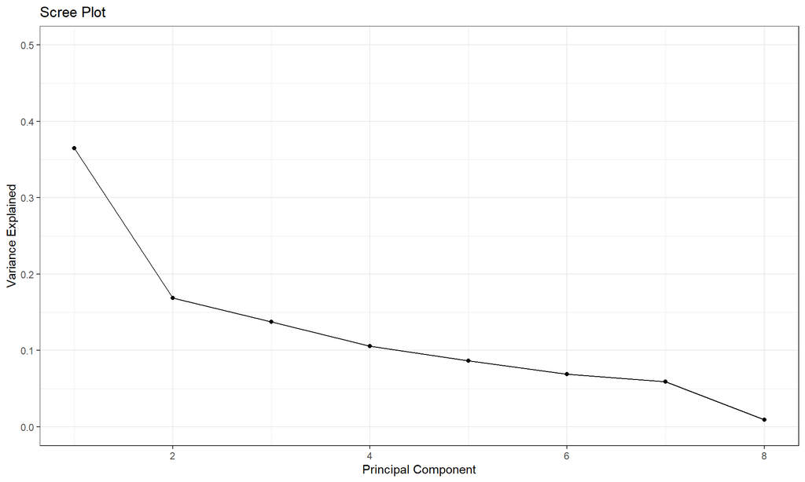

```r
var_explained <- pca_result.ca$sdev^2 / sum(pca_result.ca$sdev^2)

qplot(seq_along(var_explained), var_explained) +
  geom_line() +
  geom_point() +
  xlab("Principal Component") +
  ylab("Variance Explained") +
  ggtitle("Scree Plot") +
  ylim(0, 0.5)
```

### 6.1.1 Вопрос 5: Метод локтя

**Вопрос:** Используя метод локтя, определите оптимальное количество главных компонент. Какой процент вариации они объясняют?

**Ответ:** По scree plot видно, что после второй главной компоненты вклад в объяснённую дисперсию резко уменьшается, поэтому по критерию «локтя» оптимально использовать **две** компоненты, они описывают **53%** вариации.

## 6.2 Метод Кайзера

Метод Кайзера (Kaiser criterion) основан на собственных значениях (eigenvalues).

```r
eigenvalues <- pca_result.ca$sdev^2
eigenvalues
```

```
## [1] 2.69985243 1.24891426 1.01925126 0.78245406 0.64087834 0.50914471 0.43613505
## [8] 0.06898966
```

```r
sum(eigenvalues > 1)
```

```
## [1] 3
```

### 6.2.1 Вопрос 6: Метод Кайзера

**Вопрос:** Сколько главных компонент метод Кайзера рекомендует использовать для дальнейшего анализа?

**Ответ:** 3 главные компоненты.

**Практические рекомендации:**

1. **Цель анализа имеет значение:**
   - Для **кластеризации** часто достаточно 3-4 компонент, объясняющих основные паттерны
   - Для **предсказательного моделирования** (например, линейной регрессии) может потребоваться больше компонент
   - Для **визуализации** обычно используют 2-3 компоненты
2. **Сложность данных:**
   - В нашем датасете относительно простая структура (~10 переменных)
   - В более сложных датасетах (>50 переменных) может потребоваться больше компонент
3. **Эмпирическая проверка:**
   - Оптимальное количество компонент можно проверить, оценивая качество последующей кластеризации
   - В данном задании мы проверим различные варианты

**Для нашего анализа:** Мы будем исследовать варианты с разным количеством компонент и выберем оптимальное на основе качества кластеризации.

# 7 Интерпретация главных компонент

## 7.1 Корреляции переменных с главными компонентами

Для понимания биологического смысла главных компонент необходимо проанализировать, какие исходные переменные вносят наибольший вклад в каждую компоненту.

Вычислите корреляции между исходными переменными и главными компонентами. Создайте тепловую карту используя pheatmap().

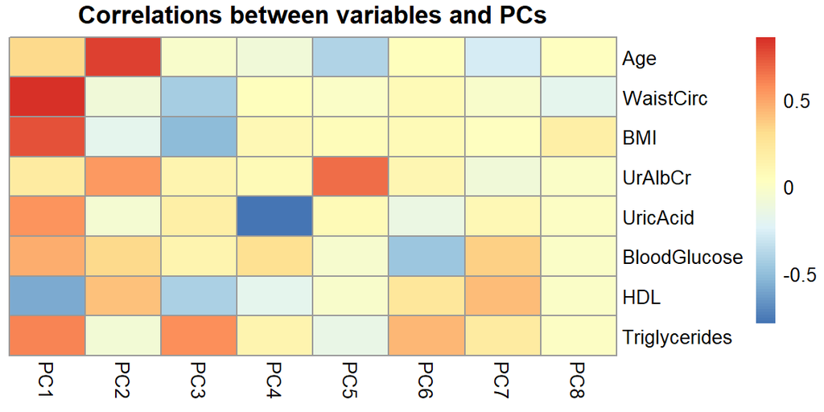

```r
loadings <- pca_result.ca$rotation

cor_mat <- sweep(loadings, 2, pca_result.ca$sdev, "*")


pheatmap(
  cor_mat,
  cluster_rows = FALSE,
  cluster_cols = FALSE,
  main = "Correlations between variables and PCs"
)
```

### 7.1.1 Вопрос 7: Интерпретация компонент

**Вопрос:** Какие две переменные наиболее сильно коррелируют с каждой из первых трех главных компонент (PC1, PC2, PC3)?

**Ответ:**

[output not shown]

# 8 Кластеризация

## 8.1 Иерархическая кластеризация

Примените иерархическую кластеризацию, постройте матрицу сопряженности и оцените совпадение предсказанных классов и диагноза с помощью Хи-квадрата.

```r
numPCs_list <- 1:6
distMethods <- c('euclidean', 'manhattan')
hclustMethods <- c('ward.D2', 'complete', 'average')

results <- data.frame(
  numPCs = integer(),
  distMethod = character(),
  hclustMethod = character(),
  X_squared = numeric(),
  p_value = numeric(),
  stringsAsFactors = FALSE
)

for(numPCs in numPCs_list){
  PCs <- pca_result.ca$x[, 1:numPCs]

  for(distMethod in distMethods){
    dist_matrix <- dist(PCs, method = distMethod)

    for(hclustMethod in hclustMethods){
      hc <- hclust(dist_matrix, method = hclustMethod)
      clusters <- cutree(hc, 2)

      contingency_table <- table(Кластер = clusters, Диагноз = target)

      chi_test <- chisq.test(contingency_table)

      results <- rbind(results, data.frame(
        numPCs = numPCs,
        distMethod = distMethod,
        hclustMethod = hclustMethod,
        X_squared = chi_test$statistic,
        p_value = chi_test$p.value
      ))
    }
  }
}

results <- results %>% arrange(desc(X_squared))
head(results, 5)
```

```
##             numPCs distMethod hclustMethod X_squared       p_value
## X-squared        1  euclidean      ward.D2  752.5190 1.136774e-165
## X-squared3       1  manhattan      ward.D2  752.5190 1.136774e-165
## X-squared18      4  euclidean      ward.D2  696.3578 1.852402e-153
## X-squared30      6  euclidean      ward.D2  694.8092 4.022473e-153
## X-squared6       2  euclidean      ward.D2  677.7367 2.075485e-149
```

### 8.1.1 Подбор оптимальных параметров

Протестируйте различные комбинации и выберите ту которая даёт лучшую кластеризацию на основне Хи-квадрата: - Количество главных компонент: 1-6 (**numPCs**) - Метрики расстояния: euclidean, manhattan (**distMethod**) - Методы связывания: ward.D2, complete, average (**hclustMethod**)

### 8.1.2 Визуализация иерархической кластеризации

Создайте тепловую карту с иерархической кластеризацией. Используйте оптимальные параметры. Добавьте аннотацию с диагнозами.

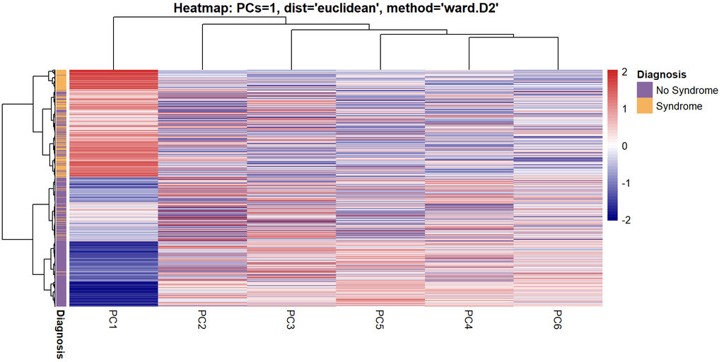

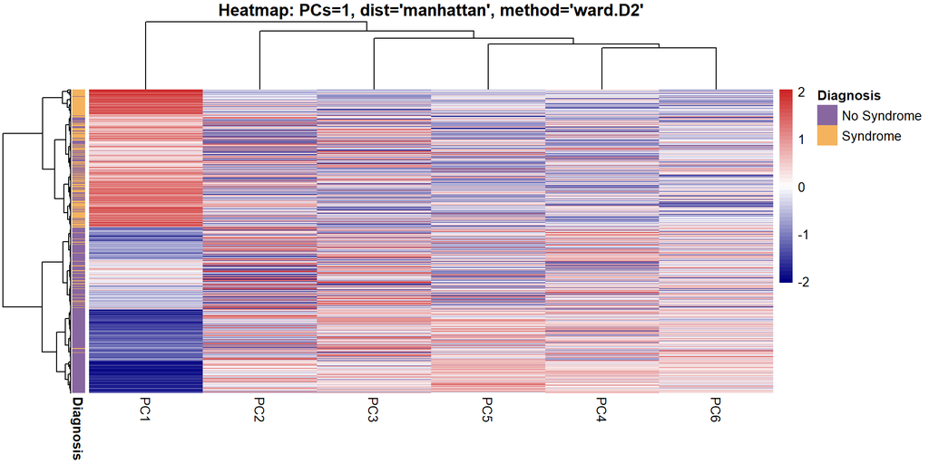

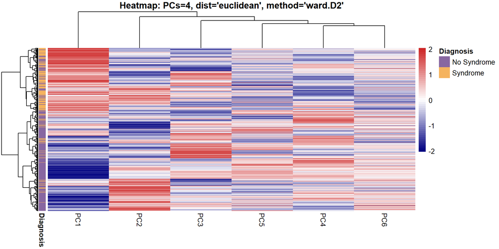

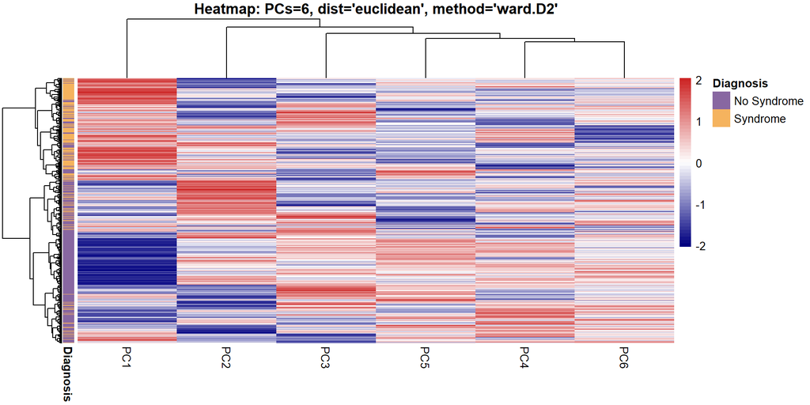

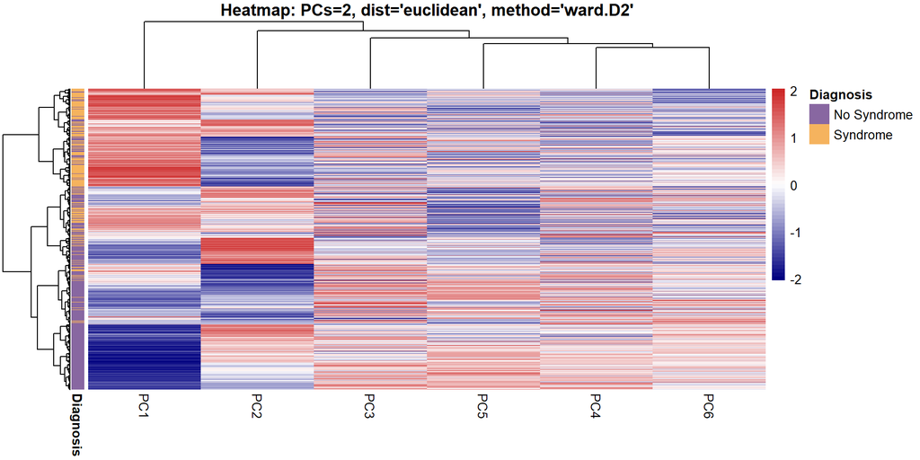

```r
best_combinations <- data.frame(
  numPCs = c(1, 1, 4, 6, 2),
  distMethod = c("euclidean", "manhattan", "euclidean", "euclidean", "euclidean"),
  hclustMethod = c("ward.D2", "ward.D2", "ward.D2", "ward.D2", "ward.D2")
)


heatmap_data <- pca_result.ca$x[, 1:6]
rownames(heatmap_data) <- paste0("Sample_", 1:nrow(heatmap_data))
annotation_row <- data.frame(
  Diagnosis = factor(target, levels = c(0,1), labels = c("No Syndrome","Syndrome"))
)
rownames(annotation_row) <- rownames(heatmap_data)

annotation_colors <- list(
  Diagnosis = c("No Syndrome" = "#8867A1", "Syndrome" = "#F5B35E")
)

for(i in 1:nrow(best_combinations)){

  numPCs <- best_combinations$numPCs[i]
  distMethod <- best_combinations$distMethod[i]
  hclustMethod <- best_combinations$hclustMethod[i]
  PCs <- pca_result.ca$x[, 1:numPCs]
  dist_matrix <- dist(PCs, method = distMethod)
  hc <- hclust(dist_matrix, method = hclustMethod)


  pheatmap(
    heatmap_data,
    cluster_rows = hc,
    cluster_cols = TRUE,
    show_rownames = FALSE,
    annotation_row = annotation_row,
    annotation_colors = annotation_colors,
    scale = "row",
    color = colorRampPalette(c("navy", "white", "firebrick3"))(50),
    main = paste0("Heatmap: PCs=", numPCs,
                  ", dist='", distMethod,
                  "', method='", hclustMethod, "'")
  )
}
```

## 8.2 K-means кластеризация

Теперь сравним результаты с методом K-means, который использует другой подход к кластеризации.

Протестируйте K-means с разным количеством главных компонент (1-6).

```r
numPCs_list <- 1:6
kmeans_results <- data.frame(
  numPCs = integer(),
  tot_withinss = numeric(),
  X_squared = numeric(),
  p_value = numeric()
)

for (numPCs in numPCs_list) {

  PCs <- pca_result.ca$x[, 1:numPCs]

  km <- kmeans(PCs, centers = 2, nstart = 25)


  contingency_table <- table(Кластер = km$cluster, Диагноз = target)


  chi_test <- chisq.test(contingency_table)

  kmeans_results <- rbind(
    kmeans_results,
    data.frame(
      numPCs = numPCs,
      tot_withinss = km$tot.withinss,
      X_squared = chi_test$statistic,
      p_value = chi_test$p.value
    )
  )
}


kmeans_results %>% arrange(desc(X_squared))
```

```
##            numPCs tot_withinss X_squared       p_value
## X-squared2      3     7395.468  753.0521 8.705089e-166
## X-squared       1     2157.763  751.8498 1.589228e-165
## X-squared1      2     5041.723  750.0431 3.926803e-165
## X-squared5      6    11857.821  747.0407 1.765492e-164
## X-squared4      5    10681.886  744.0449 7.911439e-164
## X-squared3      4     9201.530  741.0558 3.533543e-163
```

## 8.3 Вопрос 8: Оптимизация K-Means

**Вопрос:** Какое минимальное количество K даёт наилучшую кластеризацию основываясь на Хи-квадрат?

**Ответ:** 3

## 8.4 Вопрос 9: Сравнение методов кластеризации

**Вопрос:** На основе статистики χ² (Chi-squared), какой метод и с каким количеством главных компонент дает наилучший результат классификации?

**Ответ:** По значению χ²(Chi-squared) наилучший результат показывает **k-means с 3 главными компонентами**, хотя преимущество над иерархической кластеризацией минимально (k-means:753.0521 - Иерархическая: 752.5190)

# 9 Визуализация лучшей кластеризации

Постройте два биплота fviz_pca_biplot() рядом:  
1) С окраской по реальному диагнозу  
2) С окраской по кластерам лучшего метода  
Используйте gridExtra::grid.arrange(…, ncol = 2) для размещения графиков

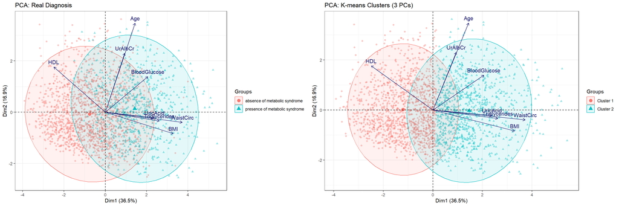

```r
best_km <- kmeans(pca_result.ca$x[, 1:3], centers = 2, nstart = 25)
clusters <- factor(best_km$cluster,
                   labels = c("Cluster 1", "Cluster 2"))

## Биплот 1: окраска по реальному диагнозу
p1 <- fviz_pca_biplot(
  pca_result.ca,
  geom = "point",
  habillage = target2,
  addEllipses = TRUE,
  ellipse.level = 0.95,
  alpha.ind = 0.4,
  col.var = "midnightblue",
  title = "PCA: Real Diagnosis"
) + theme_bw()

## Биплот 2: окраска по кластерам
p2 <- fviz_pca_biplot(
  pca_result.ca,
  geom = "point",
  habillage = clusters,
  addEllipses = TRUE,
  ellipse.level = 0.95,
  alpha.ind = 0.4,
  col.var = "midnightblue",
  title = "PCA: K-means Clusters (3 PCs)"
) + theme_bw()


gridExtra::grid.arrange(p1, p2, ncol = 2)
```

На этом заканчивается основная часть задания! Выполнив её, вы сможете получить 100 баллов!

# 10 Дополнительное задание: Попробуйте построить UMAP на исходном датасете

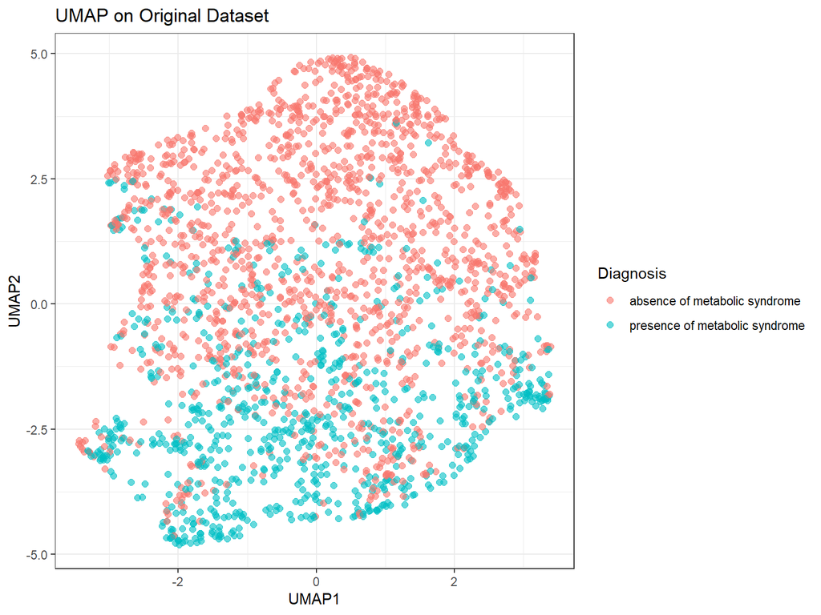

[figure not shown]

Well done

```r
umap_result <- umap(
  data_scale,
  n_neighbors = 15,
  min_dist = 0.1,
  metric = "euclidean"
)

umap_df <- as.data.frame(umap_result$layout)
colnames(umap_df) <- c("UMAP1", "UMAP2")
umap_df$Diagnosis <- target2

ggplot(umap_df, aes(x = UMAP1, y = UMAP2, color = Diagnosis)) +
  geom_point(alpha = 0.6, size = 2) +
  theme_bw() +
  labs(title = "UMAP on Original Dataset",
       color = "Diagnosis")
```